# Raster and vector data cubes in R

Edzer Pebesma, OpenGeoHub Summer School 2023

Aug 29, 2023

# Phenomena: spatially discreet or continuous?

A bit of theory.

[Stevens’ 1946 “On the Theory of Scales of Measurement”](https://www.science.org/doi/10.1126/science.103.2684.677) says there are four measurement scales: nominal, ordinal, interval and ratio. It is tempting to reduce this further to discrete (nominal, ordinal) and continuous (interval, ratio), although a count variable has a bit of both. Are the phenomena we study discreet or continuous?

We think of our phenomenon as $Z(s)$, property $Z$ is measured on object $s_i$ or at location $s$. For making progress, we need to distinguish here whether we talk about

- (non-spatial) properties of objects or locations: $Z$
  - your blood pressure and temperature are two continuous variables on a discrete object (you)
  - your DNA (or at least, the presence of a specific gene) is discrete
- spatial continuity or discreteness: $s$
  - body temperature is continuous within your body, but does not extend it; average body temperature is a property of a spatially discrete entity
  - air temperature is continuous through the air, and is spatially continuous (in $s$), as well as a continuous property (in $Z$)
  - soil type or land use type is continuous in space $s$, but discrete in value $Z$

In space-time we have for instance:

- temperature is continuous in space, time and property
- being infected with disease $x$ is discrete in space (e.g., a person) but continuous in time.
- a remote sensing image is (semi-) continuous in space $s$ and value $Z$ (energy) but the *observation* is discrete in time (snapshot); the energy phenomena is continuous in time

We often associate

- *vector data* with *spatially* discrete phenomena (“features”)
- *raster data* with *spatially* continuous phenomena (“fields”, coverages)

- locations of things (trees, persons, cars)
- locations for *measurements* of spatially continuous phenomena (air temperature, air quality),

LINESTRINGs can reflect

- roads, railways or borders
- contour lines with constant values of spatially continuous elevation

and POLYGONs can reflect

- administrative regions, voting districts or forest stands
- the boundaries of of a spatially continuous discrete variable like land use or soil type

Linestring and polygon geometries are collections of points, and attributes associated with the geometry can be associated either with

- all of the points (1 value: population count, population density, size or length)
- each of the points (soil type, land use, contour line elevation)

We say for the first relation that the attribute has *block support*, and for the second that it has *point support*, following the geostatistical literature. [Further reading](https://r-spatial.org/book/05-Attributes.html).

Getting this wrong, e.g. when downscaling polygons, may be a source of gross error in subsequent analysis. Before you analyse data, it makes a lot of sense to not only consider the measurement scale of your attribute $Z$, but also whether it is spatially continuous or discrete ($s$). If it is discrete, counting, sums and spatial densities make sense, if it is continuous averaging and interpolation (prediction over continuous space) make sense.

```r
library(sf)
(pol = st_polygon(list(rbind(c(0,0), c(2,0), c(2,2), c(0,2), c(0,0)))))
```

```
## POLYGON ((0 0, 2 0, 2 2, 0 2, 0 0))
```

```r
(point = st_point(c(1,1)))
```

```
## POINT (1 1)
```

```r
st_intersects(point, pol)
```

```
## Sparse geometry binary predicate list of length 1, where the predicate
## was `intersects'
##  1: 1
```

Now suppose we know two properties of the polygon: total population and land use:

```r
(pol.sf = st_sf(population = 5000, land_use = "urban", geom = st_sfc(pol)))
```

```
## Simple feature collection with 1 feature and 2 fields
## Geometry type: POLYGON
## Dimension:     XY
## Bounding box:  xmin: 0 ymin: 0 xmax: 2 ymax: 2
## CRS:           NA
##   population land_use                           geom
## 1       5000    urban POLYGON ((0 0, 2 0, 2 2, 0 ...
```

If we now intersect `point` with `pol.sf`, should it retain the associated attributes?

```r
st_intersection(pol.sf, point)
```

```
## Warning: attribute variables are assumed to be spatially constant throughout
## all geometries
```

```
## Simple feature collection with 1 feature and 2 fields
## Geometry type: POINT
## Dimension:     XY
## Bounding box:  xmin: 1 ymin: 1 xmax: 1 ymax: 1
## CRS:           NA
##   population land_use        geom
## 1       5000    urban POINT (1 1)
```

How do we get rid of this warning? By setting the attribute-geometry relationsip (agr):

```r
st_agr(pol.sf) = c(population = "aggregate", land_use = "constant")
st_intersection(pol.sf["land_use"], point)
```

```
## Simple feature collection with 1 feature and 1 field
## Geometry type: POINT
## Dimension:     XY
## Bounding box:  xmin: 1 ymin: 1 xmax: 1 ymax: 1
## CRS:           NA
##   land_use        geom
## 1    urban POINT (1 1)
```

No warning!

```r
st_intersection(pol.sf["population"], point)
```

```
## Warning: attribute variables are assumed to be spatially constant throughout
## all geometries
```

```
## Simple feature collection with 1 feature and 1 field
## Geometry type: POINT
## Dimension:     XY
## Bounding box:  xmin: 1 ymin: 1 xmax: 1 ymax: 1
## CRS:           NA
##   population        geom
## 1       5000 POINT (1 1)
```

Warning justified: maybe this should be an error, `population` be returned `NA`.

# Tidy data?

Recall [tidy data](https://www.jstatsoft.org/article/view/v059i10): *each variable is a column, each observation is a row, and each type of observational unit is a table.*

```r
head(mtcars)
```

```
##                    mpg cyl disp  hp drat    wt  qsec vs am gear carb
## Mazda RX4         21.0   6  160 110 3.90 2.620 16.46  0  1    4    4
## Mazda RX4 Wag     21.0   6  160 110 3.90 2.875 17.02  0  1    4    4
## Datsun 710        22.8   4  108  93 3.85 2.320 18.61  1  1    4    1
## Hornet 4 Drive    21.4   6  258 110 3.08 3.215 19.44  1  0    3    1
## Hornet Sportabout 18.7   8  360 175 3.15 3.440 17.02  0  0    3    2
## Valiant           18.1   6  225 105 2.76 3.460 20.22  1  0    3    1
```

`sf` and `geopandas` objects belong to this category.

## Enter raster data and data cubes

[See here](https://r-spatial.org/book/06-Cubes.html)

## Limits of tables

For raster data, we can, obviously, put things in tables, in different ways

```r
library(stars)
L7_ETMs |> as.data.frame() |> head()
```

```
##          x       y band L7_ETMs
## 1 288790.5 9120747    1      69
## 2 288819.0 9120747    1      69
## 3 288847.5 9120747    1      63
## 4 288876.0 9120747    1      60
## 5 288904.5 9120747    1      61
## 6 288933.0 9120747    1      61
```

```r
L7_ETMs |> st_as_sf(long = TRUE, as_points = TRUE) |> head()
```

```
## Simple feature collection with 6 features and 2 fields
## Geometry type: POINT
## Dimension:     XY
## Bounding box:  xmin: 288790.5 ymin: 9120747 xmax: 288933 ymax: 9120747
## Projected CRS: SIRGAS 2000 / UTM zone 25S
##   band L7_ETMs                 geometry
## 1    1      69 POINT (288790.5 9120747)
## 2    1      69   POINT (288819 9120747)
## 3    1      63 POINT (288847.5 9120747)
## 4    1      60   POINT (288876 9120747)
## 5    1      61 POINT (288904.5 9120747)
## 6    1      61   POINT (288933 9120747)
```

```r
L7_ETMs |> st_as_sf(as_points = TRUE) |> head()
```

```
## Simple feature collection with 6 features and 6 fields
## Geometry type: POINT
## Dimension:     XY
## Bounding box:  xmin: 288790.5 ymin: 9120747 xmax: 288933 ymax: 9120747
## Projected CRS: SIRGAS 2000 / UTM zone 25S
##   L7_ETMs.V1 L7_ETMs.V2 L7_ETMs.V3 L7_ETMs.V4 L7_ETMs.V5 L7_ETMs.V6
## 1         69         56         46         79         86         46
## 2         69         57         49         75         88         49
## 3         63         52         45         66         75         41
## 4         60         45         35         66         69         38
## 5         61         52         44         76         92         60
## 6         61         50         37         78         74         38
##                   geometry
## 1 POINT (288790.5 9120747)
## 2   POINT (288819 9120747)
## 3 POINT (288847.5 9120747)
## 4   POINT (288876 9120747)
## 5 POINT (288904.5 9120747)
## 6   POINT (288933 9120747)
```

```r
L7_ETMs |> st_as_sf(as_points = FALSE) |> head()
```

```
## Simple feature collection with 6 features and 6 fields
## Geometry type: POLYGON
## Dimension:     XY
## Bounding box:  xmin: 288776.3 ymin: 9120732 xmax: 288947.3 ymax: 9120761
## Projected CRS: SIRGAS 2000 / UTM zone 25S
##   L7_ETMs.V1 L7_ETMs.V2 L7_ETMs.V3 L7_ETMs.V4 L7_ETMs.V5 L7_ETMs.V6
## 1         69         56         46         79         86         46
## 2         69         57         49         75         88         49
## 3         63         52         45         66         75         41
## 4         60         45         35         66         69         38
## 5         61         52         44         76         92         60
## 6         61         50         37         78         74         38
##                         geometry
## 1 POLYGON ((288776.3 9120761,...
## 2 POLYGON ((288804.8 9120761,...
## 3 POLYGON ((288833.3 9120761,...
## 4 POLYGON ((288861.8 9120761,...
## 5 POLYGON ((288890.3 9120761,...
## 6 POLYGON ((288918.8 9120761,...
```

In principle, everything you can do with arrays, you can do with tables; not vice versa. Why then would you work with arrays?

## Why/when would you stick to arrays?

If you use arrays, you have the advantage of:

```
* guarantee of complete data: "empty" fields are filled with 0 (count) or NA (continuous, or nominal)
* there is no need to take care of completeness, data are complete by construction
* in-memory arrays have a continous memory layout, hence indexes are for free: we "know" where each data value is ("[geotransform](https://r-spatial.org/book/06-Cubes.html#regular-dimensions-gdals-geotransform)")
* for larger datasets: arrays form an easy and useful abstraction
* array [_operations_](https://r-spatial.org/book/06-Cubes.html#sec-dcoperations) are a powerful and comprehensive means to design and communicate analysis, and are much harder to carry out with tables
```

```r
stars:::get_geotransform(L7_ETMs)
```

```
## [1]  288776.3      28.5       0.0 9120760.8       0.0     -28.5
```

# Datacube datasets stored in tables:

## long table:

Each record (row) reflects a unique combination of space (state) and time (year):

```r
data(Produc, package = "plm")
head(Produc)
```

```
##     state year region     pcap     hwy   water    util       pc   gsp    emp
## 1 ALABAMA 1970      6 15032.67 7325.80 1655.68 6051.20 35793.80 28418 1010.5
## 2 ALABAMA 1971      6 15501.94 7525.94 1721.02 6254.98 37299.91 29375 1021.9
## 3 ALABAMA 1972      6 15972.41 7765.42 1764.75 6442.23 38670.30 31303 1072.3
## 4 ALABAMA 1973      6 16406.26 7907.66 1742.41 6756.19 40084.01 33430 1135.5
## 5 ALABAMA 1974      6 16762.67 8025.52 1734.85 7002.29 42057.31 33749 1169.8
## 6 ALABAMA 1975      6 17316.26 8158.23 1752.27 7405.76 43971.71 33604 1155.4
##   unemp
## 1   4.7
## 2   5.2
## 3   4.7
## 4   3.9
## 5   5.5
## 6   7.7
```

```r
nrow(Produc)
```

```
## [1] 816
```

```r
length(unique(Produc$state)) * length(unique(Produc$year))
```

```
## [1] 816
```

```r
# but do we acually have all combinations?
with(Produc, length(unique(paste(state, year, sep = ":"))))
```

```
## [1] 816
```

## space-wide table:

different records (rows) correspond to different times, columns to different locations:

```r
data(wind, package = "gstat")
head(wind)
```

```
##   year month day   RPT   VAL   ROS   KIL   SHA  BIR   DUB   CLA   MUL   CLO
## 1   61     1   1 15.04 14.96 13.17  9.29 13.96 9.87 13.67 10.25 10.83 12.58
## 2   61     1   2 14.71 16.88 10.83  6.50 12.62 7.67 11.50 10.04  9.79  9.67
## 3   61     1   3 18.50 16.88 12.33 10.13 11.17 6.17 11.25  8.04  8.50  7.67
## 4   61     1   4 10.58  6.63 11.75  4.58  4.54 2.88  8.63  1.79  5.83  5.88
## 5   61     1   5 13.33 13.25 11.42  6.17 10.71 8.21 11.92  6.54 10.92 10.34
## 6   61     1   6 13.21  8.12  9.96  6.67  5.37 4.50 10.67  4.42  7.17  7.50
##     BEL   MAL
## 1 18.50 15.04
## 2 17.54 13.83
## 3 12.75 12.71
## 4  5.46 10.88
## 5 12.92 11.83
## 6  8.12 13.17
```

## time-wide table:

Different records (rows) correspond to different locations, columns to different times (xxx74: xxx for 1974; xxx79: xxx for 1979)

```r
library(sf)
system.file("gpkg/nc.gpkg", package="sf") |> read_sf() -> nc
head(nc)
```

```
## Simple feature collection with 6 features and 14 fields
## Geometry type: MULTIPOLYGON
## Dimension:     XY
## Bounding box:  xmin: -81.74107 ymin: 36.07282 xmax: -75.77316 ymax: 36.58965
## Geodetic CRS:  NAD27
## # A tibble: 6 × 15
##    AREA PERIMETER CNTY_ CNTY_ID NAME   FIPS  FIPSNO CRESS_ID BIR74 SID74 NWBIR74
##   <dbl>     <dbl> <dbl>   <dbl> <chr>  <chr>  <dbl>    <int> <dbl> <dbl>   <dbl>
## 1 0.114      1.44  1825    1825 Ashe   37009  37009        5  1091     1      10
## 2 0.061      1.23  1827    1827 Alleg… 37005  37005        3   487     0      10
## 3 0.143      1.63  1828    1828 Surry  37171  37171       86  3188     5     208
## 4 0.07       2.97  1831    1831 Curri… 37053  37053       27   508     1     123
## 5 0.153      2.21  1832    1832 North… 37131  37131       66  1421     9    1066
## 6 0.097      1.67  1833    1833 Hertf… 37091  37091       46  1452     7     954
## # ℹ 4 more variables: BIR79 <dbl>, SID79 <dbl>, NWBIR79 <dbl>,
## #   geom <MULTIPOLYGON [°]>
```

# Creating datacubes from non-datacube data

## Foot-and-mouth disease cases

```r
data(fmd, package = 'stpp')
head(fmd)
```

```
##           X      Y ReportedDay
## [1,] 350850 557590          28
## [2,] 337320 569500          28
## [3,] 341730 572090          28
## [4,] 350410 527040          28
## [5,] 347800 541850          29
## [6,] 356900 541120          29
```

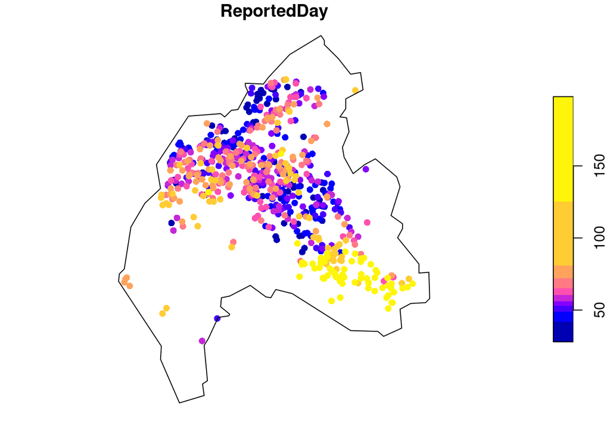

```r
data("northcumbria", package = 'stpp')
fmd.sf = st_as_sf(as.data.frame(fmd), coords = c('X', 'Y'))
n = nrow(northcumbria)
nh = st_sfc(st_polygon(list(northcumbria[c(1:n,1),])))
plot(fmd.sf, pch = 16, reset = FALSE, extent = nh, breaks = "quantile")
plot(nh, add = TRUE)
```

Create an empty datacube covering the space-time area, and count the number of cases in each grid cell:

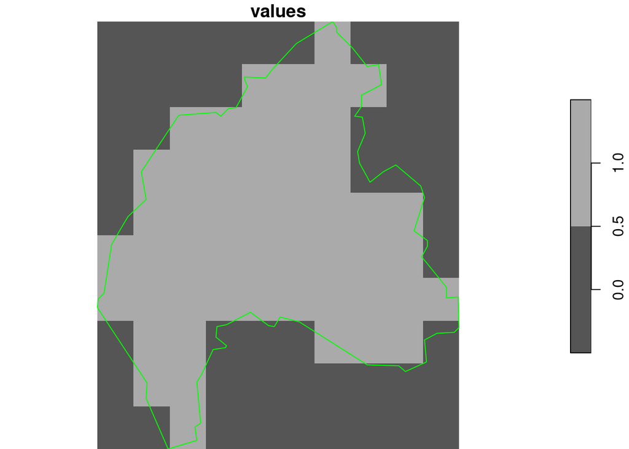

```r
library(stars)
st = st_as_stars(nh, nx = 10, ny = 10)
plot(st, reset = FALSE)
plot(nh, add = TRUE, border = 'green')
```

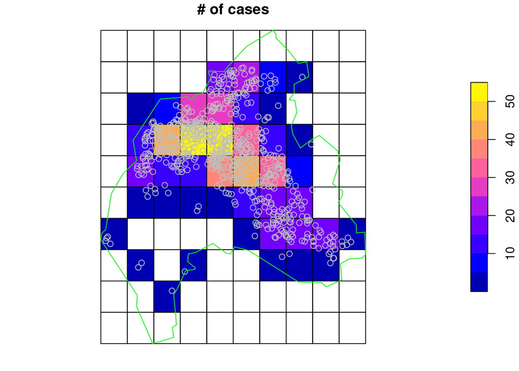

```r
a = aggregate(fmd.sf, st_as_sf(st), FUN = length)
plot(a, main = "# of cases", reset = FALSE)
plot(fmd.sf, add = TRUE, col = 'grey')
plot(nh, border = 'green', add = TRUE)
```

See https://www.jstatsoft.org/article/view/v053i02 for a more elaborate approach to model these data statistically.

## Hurricanes

See [hurricanes.Rmd](https://github.com/edzer/OGH23/blob/main/hurdat.Rmd), output

## OD

See example in SDS: https://r-spatial.org/book/07-Introsf.html#sec-oddc

## `nc`: a categorical dimension

```r
library(sf)
nc = read_sf(system.file("gpkg/nc.gpkg", package="sf"))
m = st_set_geometry(nc, NULL)
n = as.matrix(m[c("BIR74", "SID74", "NWBIR74", "BIR79", "SID79", "NWBIR79")]) # 100 x 6
dim(n) = c(county = 100, var = 3, year = 2) # 100 x 3 x 2
dimnames(n) = list(county = nc$NAME, var = c("BIR", "SID", "NWBIR"), year = c(1974, 1979))
library(stars)
(st = st_as_stars(pop = n)) # without geometries
```

```
## stars object with 3 dimensions and 1 attribute
## attribute(s):
##      Min. 1st Qu. Median     Mean 3rd Qu.  Max.
## pop     0       8    538 1657.032    1784 30757
## dimension(s):
##        from  to              values
## county    1 100  Ashe,...,Brunswick
## var       1   3 BIR  , SID  , NWBIR
## year      1   2          1974, 1979
```

```r
foo <- st |> st_set_dimensions(1, st_geometry(nc)) # with
foo
```

```
## stars object with 3 dimensions and 1 attribute
## attribute(s):
##      Min. 1st Qu. Median     Mean 3rd Qu.  Max.
## pop     0       8    538 1657.032    1784 30757
## dimension(s):
##        from  to refsys point
## county    1 100  NAD27 FALSE
## var       1   3     NA    NA
## year      1   2     NA    NA
##                                                               values
## county MULTIPOLYGON (((-81.47276...,...,MULTIPOLYGON (((-78.65572...
## var                                              BIR  , SID  , NWBIR
## year                                                      1974, 1979
```

```r
st_bbox(foo)
```

```
##      xmin      ymin      xmax      ymax
## -84.32385  33.88199 -75.45698  36.58965
```

```r
(x = st_as_sf(foo))
```

```
## Simple feature collection with 100 features and 6 fields
## Geometry type: MULTIPOLYGON
## Dimension:     XY
## Bounding box:  xmin: -84.32385 ymin: 33.88199 xmax: -75.45698 ymax: 36.58965
## Geodetic CRS:  NAD27
## First 10 features:
##    BIR.1974 SID.1974 NWBIR.1974 BIR.1979 SID.1979 NWBIR.1979
## 1      1091        1         10     1364        0         19
## 2       487        0         10      542        3         12
## 3      3188        5        208     3616        6        260
## 4       508        1        123      830        2        145
## 5      1421        9       1066     1606        3       1197
## 6      1452        7        954     1838        5       1237
## 7       286        0        115      350        2        139
## 8       420        0        254      594        2        371
## 9       968        4        748     1190        2        844
## 10     1612        1        160     2038        5        176
##                            county
## 1  MULTIPOLYGON (((-81.47276 3...
## 2  MULTIPOLYGON (((-81.23989 3...
## 3  MULTIPOLYGON (((-80.45634 3...
## 4  MULTIPOLYGON (((-76.00897 3...
## 5  MULTIPOLYGON (((-77.21767 3...
## 6  MULTIPOLYGON (((-76.74506 3...
## 7  MULTIPOLYGON (((-76.00897 3...
## 8  MULTIPOLYGON (((-76.56251 3...
## 9  MULTIPOLYGON (((-78.30876 3...
## 10 MULTIPOLYGON (((-80.02567 3...
```

```r
frac = function(x) x[2] / x[1]
frac2 = function(x) c(sidsr = x[2] / x[1], nwbr = x[3] / x[1])
frac2an = function(x) c(x[2] / x[1], x[3] / x[1])
st_apply(foo, c(1,3), frac)
```

```
## stars object with 2 dimensions and 1 attribute
## attribute(s):
##       Min.     1st Qu.      Median        Mean     3rd Qu.       Max.
## frac     0 0.001197874 0.001930504 0.002042241 0.002599348 0.00955414
## dimension(s):
##        from  to refsys point
## county    1 100  NAD27 FALSE
## year      1   2     NA    NA
##                                                               values
## county MULTIPOLYGON (((-81.47276...,...,MULTIPOLYGON (((-78.65572...
## year                                                      1974, 1979
```

```r
st_apply(foo, c(1,3), frac2)
```

```
## stars object with 3 dimensions and 1 attribute
## attribute(s):
##      Min.     1st Qu.      Median      Mean   3rd Qu.      Max.
## pop     0 0.001923331 0.005119673 0.1567576 0.3065298 0.7727273
## dimension(s):
##        from  to refsys point
## frac2     1   2     NA    NA
## county    1 100  NAD27 FALSE
## year      1   2     NA    NA
##                                                               values
## frac2                                                   sidsr, nwbr
## county MULTIPOLYGON (((-81.47276...,...,MULTIPOLYGON (((-78.65572...
## year                                                      1974, 1979
```

```r
st_apply(foo, c(1,3), frac2an)
```

```
## stars object with 3 dimensions and 1 attribute
## attribute(s):
##      Min.     1st Qu.      Median      Mean   3rd Qu.      Max.
## pop     0 0.001923331 0.005119673 0.1567576 0.3065298 0.7727273
## dimension(s):
##         from  to refsys point
## frac2an    1   2     NA    NA
## county     1 100  NAD27 FALSE
## year       1   2     NA    NA
##                                                                values
## frac2an                                                          NULL
## county  MULTIPOLYGON (((-81.47276...,...,MULTIPOLYGON (((-78.65572...
## year                                                       1974, 1979
```

```r
library(abind)
aperm(st_apply(foo, c(1,3), frac2), c("county", "year", "frac2"))
```

```
## stars object with 3 dimensions and 1 attribute
## attribute(s):
##      Min.     1st Qu.      Median      Mean   3rd Qu.      Max.
## pop     0 0.001923331 0.005119673 0.1567576 0.3065298 0.7727273
## dimension(s):
##        from  to refsys point
## county    1 100  NAD27 FALSE
## year      1   2     NA    NA
## frac2     1   2     NA    NA
##                                                               values
## county MULTIPOLYGON (((-81.47276...,...,MULTIPOLYGON (((-78.65572...
## year                                                      1974, 1979
## frac2                                                   sidsr, nwbr
```

```r
split(foo, 2)
```

```
## stars object with 2 dimensions and 3 attributes
## attribute(s):
##        Min. 1st Qu. Median     Mean 3rd Qu.  Max.
## BIR     248 1176.75   2265 3761.770 4450.75 30757
## SID       0    2.00      5    7.515    9.00    57
## NWBIR     1  206.00    742 1201.810 1315.75 11631
## dimension(s):
##        from  to refsys point
## county    1 100  NAD27 FALSE
## year      1   2     NA    NA
##                                                               values
## county MULTIPOLYGON (((-81.47276...,...,MULTIPOLYGON (((-78.65572...
## year                                                      1974, 1979
```

```r
split(foo, 3)
```

```
## stars object with 2 dimensions and 2 attributes
## attribute(s):
##       Min. 1st Qu. Median     Mean 3rd Qu.  Max.
## 1974     0       8  501.5 1452.367 1580.50 21588
## 1979     0       9  614.0 1861.697 2040.25 30757
## dimension(s):
##        from  to refsys point
## county    1 100  NAD27 FALSE
## var       1   3     NA    NA
##                                                               values
## county MULTIPOLYGON (((-81.47276...,...,MULTIPOLYGON (((-78.65572...
## var                                              BIR  , SID  , NWBIR
```

```r
# subset vector cube:
foo[nc[1]]
```

```
## stars object with 3 dimensions and 1 attribute
## attribute(s):
##      Min. 1st Qu. Median     Mean 3rd Qu.  Max.
## pop     0       8    538 1657.032    1784 30757
## dimension(s):
##        from  to refsys point
## county    1 100  NAD27 FALSE
## var       1   3     NA    NA
## year      1   2     NA    NA
##                                                               values
## county MULTIPOLYGON (((-81.47276...,...,MULTIPOLYGON (((-78.65572...
## var                                              BIR  , SID  , NWBIR
## year                                                      1974, 1979
```

# Vector data cubes from raster data cubes

Consider the following temperature reanalysis data, taken from this file.

We can read this NetCDF file using either of two ways:

```r
u = "https://psl.noaa.gov/repository/entry/get/skt.sfc.mon.mean.nc?entryid=synth%3Ae570c8f9-ec09-4e89-93b4-babd5651e7a9%3AL25jZXAucmVhbmFseXNpczIuZGVyaXZlZC9nYXVzc2lhbl9ncmlkL3NrdC5zZmMubW9uLm1lYW4ubmM%3D"
f = 'skt.sfc.mon.mean.nc'
if (!file.exists(f)) {
  download.file(u, f)
}
library(stars)
read_stars(f) # GDAL RasterLayer
```

```
## stars object with 3 dimensions and 1 attribute
## attribute(s), summary of first 1e+05 cells:
##                           Min. 1st Qu. Median     Mean 3rd Qu.   Max.
## skt.sfc.mon.mean.nc [K] 196.82  265.15  283.4 278.1943  297.35 313.02
## dimension(s):
##      from  to  offset  delta  refsys                    values x/y
## x       1 192 -0.9375  1.875      NA                      NULL [x]
## y       1  94   89.49 -1.904      NA                      NULL [y]
## time    1 535      NA     NA POSIXct 1979-01-01,...,2023-07-01
```

```r
read_mdim(f)  # GDAL Multidimensional Array API
```

```
## stars object with 3 dimensions and 1 attribute
## attribute(s), summary of first 1e+05 cells:
##           Min. 1st Qu. Median     Mean 3rd Qu.   Max.
## skt [K] 196.82  265.15  283.4 278.1943  297.35 313.02
## dimension(s):
##      from  to  offset delta  refsys
## lon     1 192 -0.9375 1.875  WGS 84
## lat     1  94      NA    NA  WGS 84
## time    1 535      NA    NA POSIXct
##                                             values x/y
## lon                                           NULL [x]
## lat  [89.48645,87.59755),...,[-87.59755,-89.48645) [y]
## time                     1979-01-01,...,2023-07-01
```

We will continue with the first in order to have a regular grid; another approach would have been to resample/warp the rectilinear grid.

Sampling this at two locations:

```r
skt = read_stars('skt.sfc.mon.mean.nc')
st_crs(skt) = 'OGC:CRS84'
pts = st_sfc(st_point(c(7, 52)), st_point(c(16.9, 52)), crs = st_crs(skt))
e = st_extract(skt, pts)
library(xts)
```

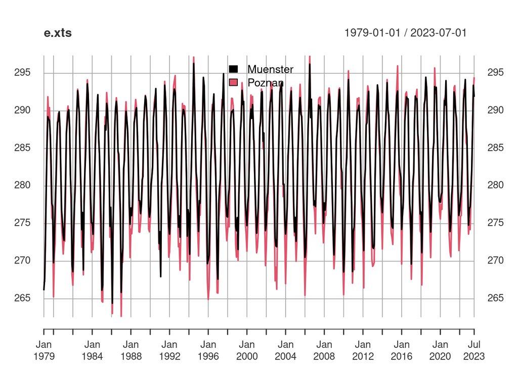

```r
e.xts = as.xts(e)
colnames(e.xts) = c("Muenster", "Poznan")
plot(e.xts, legend.loc = "top")
```

Computing the means over three countries:

```r
ne = rnaturalearth::ne_countries(returnclass = "sf")
```

[output not shown]

```r
library(dplyr)
```

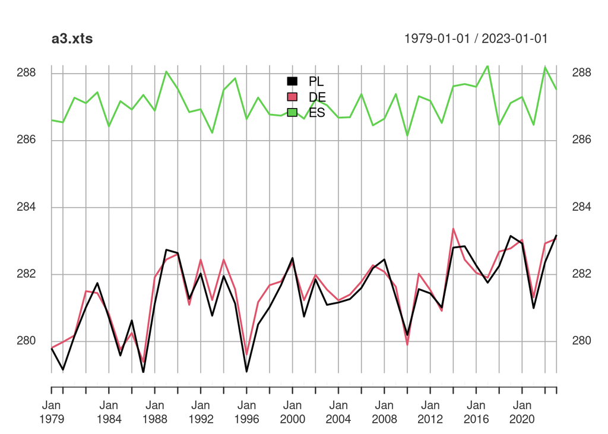

```r
sel = c("PL", "DE", "ES")
ne |> filter(iso_a2 %in% sel) -> ne3
aggregate(skt, ne3, FUN=mean, na.rm = TRUE) |>
  aggregate(by = "year", FUN=mean, na.rm = TRUE) |>
  as.xts() -> a3.xts
colnames(a3.xts) = sel
plot(a3.xts, legend.loc = "top")
```